# Bayesian model of regularization

Vanessa Ferdinand

7/3/2020

## *Draft 1 - document still in progress*

## Overview

This document explains the beta-binomial Bayesian model used in Reali & Griffiths (2008).

*I’ll explain their model using examples from the problem domain of flipping a coin and trying to infer the bias on the coin from the outcome of the flips you observe.*

## The model

### Prior

The prior distribution is a [beta distribution](https://en.wikipedia.org/wiki/Beta_distribution).

$Beta(\alpha,\beta) = \frac{\Gamma(\alpha+\beta)}{\Gamma(\alpha)\Gamma(\beta)} \theta^{\alpha-1}(1-\theta)^{\beta-1}$

*This is a distribution over your beliefs in what the bias of the coin could be, before you see any data.*

$\theta =$ each **hypothesis**, or bias that the coin could have.  
$\alpha$ and $\beta$ control the shape of the prior.

Note: Reali & Griffiths (2008) restrict their model to a symmetrical prior, meaning $\alpha=\beta$, and use a single parameter with the notation $\frac{a}{2}$, as in $Beta(\frac{a}{2},\frac{a}{2})$. I’m going to stick to $Beta(\alpha,\beta)$ in this document so you can explore asymmetrical priors too. But if you want to replicate RG, just use $\alpha=\beta$.

**Examples**:  
When $\alpha=\beta=1$, the prior is uniform. Meaning the learner has equal belief in all possible values of $\theta$ before they see any data.  
When $\alpha=\beta<1$, the learner expects $\theta$ to be regular (i.e. peaked at $\theta=0$ and $\theta=1$).  
When $\alpha=\beta>1$, the learner expects $\theta$ to be variable (i.e. peaked at $\theta=0.5$)  
When $\alpha=5$ and $\beta=2$, the learner expects $\theta=0.8$ and biases around that to be most likely.

Plot a beta distribution. Change the parameters `alpha` and `beta` below:

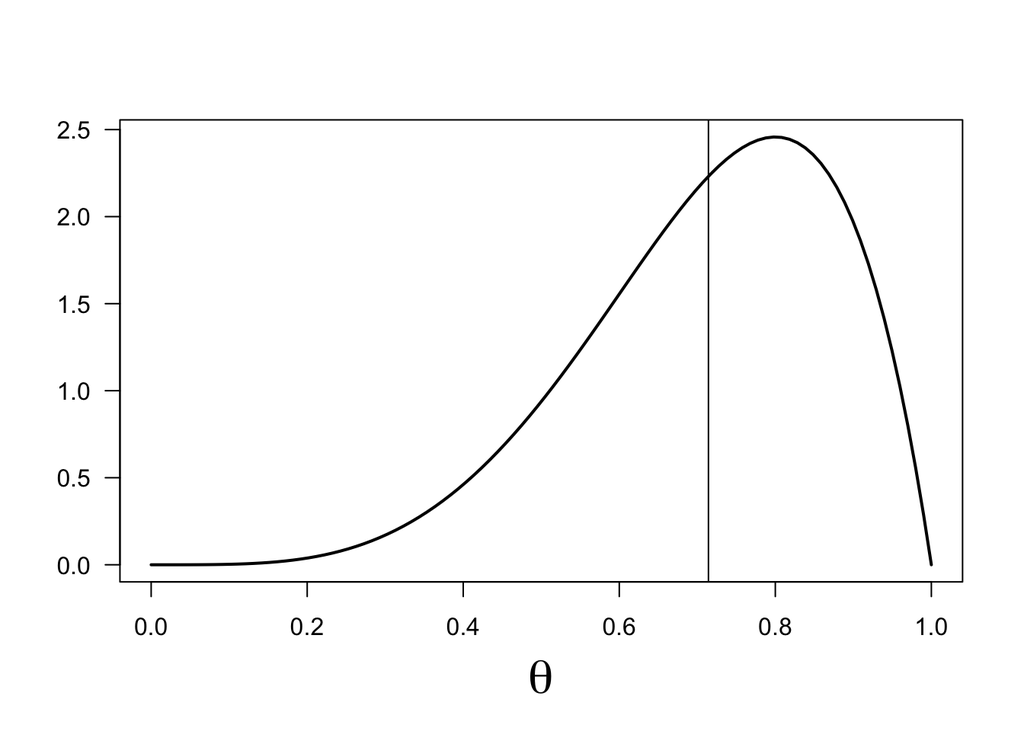

```r
alpha <- 5
beta <- 2

beta_mean <- alpha/(alpha+beta)  # here's the mean of a beta distribution
x <- seq(0, 1, length=100)       # compute dbeta() for these x values
y <- dbeta(x,alpha,beta)
plot(x, y, type="l", las=1, lwd=2, xlab=bquote(theta), ylab="", cex.lab=2)
abline(v=beta_mean)
```

### Likelihood

The likelihood follows the [binomial distribution](https://en.wikipedia.org/wiki/Binomial_distribution).

$p(k|N,\theta) = {N\choose k} \theta^k (1-\theta)^{N-k}$

*If we were flipping a coin with bias $= \theta$, then this distribution tells us the probability of getting any outcome of $k$ “successes” from $N$ flips.*

Plot a binomial distribution for all possible $k$ successes from $N$ flips, given one particular hypothesis $\theta$:

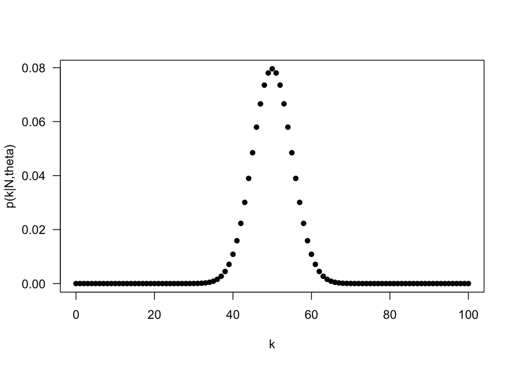

```r
N <- 100
theta <- 0.5

k <- seq(0, N, by=1)  # all possible outcomes of k for N flips
y <- dbinom(k,N,theta)
plot(k, y, las=1, lwd=2, xlab="k", ylab="p(k|N,theta)", pch=16)
```

Note: I’ve plotted this as points because k is discrete. $\theta$ in the other plots can be continuous.

### Posterior

The posterior is also a [beta distribution](https://en.wikipedia.org/wiki/Beta_distribution).

The posterior tells you what your relative belief in all hypotheses are after observing whatever data you just saw.

Because the Binomial likelihood and Beta prior are [conjugate](https://en.wikipedia.org/wiki/Conjugate_prior), it’s very simple to calculate the posterior:

$Beta(\alpha+s,\beta+f)$

Where:  
$s =$ the successes (i.e. $k$), which in our notation is $x$  
$f =$ the failures (i.e. $N-k$), which in our notation is $(1-x)$

Plot the posterior distribution for any prior and any hypothetical data:

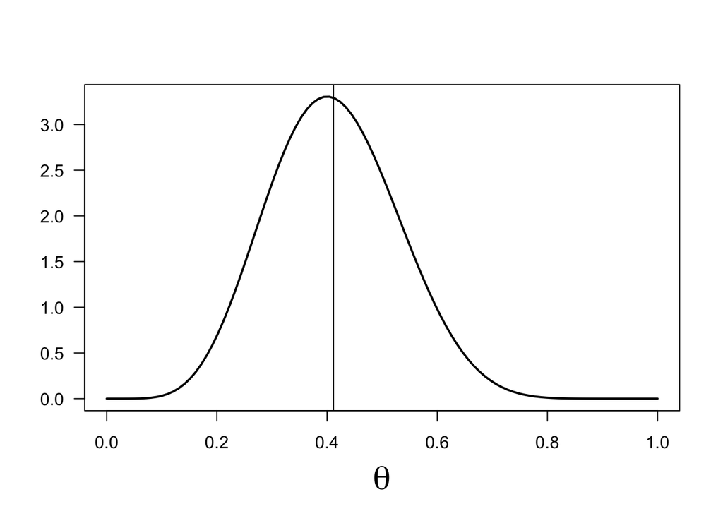

```r
k <- 5        # number of observations where the outcome = v1
N <- 10        # total number of observations (must be larger than k)

alpha <- 2    # parameters of prior
beta <- 5

beta_mean <- (alpha+k)/((alpha+k)+(beta+N-k))  # here's the mean of the posterior
x <- seq(0, 1, length=100)                     # compute dbeta() for these values of theta
y <- dbeta(x,alpha+k,beta+N-k)
plot(x, y, type="l", las=1, lwd=2, xlab=bquote(theta), ylab="", cex.lab=2)
abline(v=beta_mean)
```

**Interpretation of posterior**: The beta distribution is a [probability density function](https://en.wikipedia.org/wiki/Probability_density_function) of a continuous random variable. This means the absolute belief in any hypothesis is actually zero - but the relative likelihood of any set of beliefs can be calulated. So if you want to know what your relative belief in $\theta = (0.5, 0.7,$ or $0.9)$ is, then compute the ratio of those hypotheses’ values on the posterior distribution:

```r
thetas <- c(.5,.7,.9)
ys <- dbeta(thetas,alpha+k,beta+N-k)
relative_beliefs <- ys/sum(ys)
print(format(relative_beliefs, scientific=F)) # in case they print in scientific notation
```

```
## [1] "0.92945632024" "0.07052749397" "0.00001618579"
```

### Hypothesis choice

Ok now we’ve computed the posterior. But the agent still needs to choose a hypothesis from the posterior to generate data from.

RG have the agent sample from the posterior (double-check):

```r
# NOT RIGHT YET
#sample(x,prob=(y/sum(y)))
```

But you could also choose the one on the mean of the distribution. Calculate the beta mean:

```r
beta_mean <- function(alpha,beta,k,N) {
    return((alpha+k)/((alpha+k)+(beta+N-k)))
}
chosen_theta <- beta_mean(alpha,beta,k,N)
```

Or you could choose the MAP hypothesis (i.e. the one on the mode or peak of the distribution). Calculate the beta mode:

```r
beta_mode <- function(alpha,beta,k,N) {
    if (alpha+k > 1 && beta+N-k > 1) { answer <- (alpha+k-1)/(alpha+k+beta+N-k-2) }
    if (alpha+k == 1 && beta+N-k == 1) { answer <- "all values between 0 and 1 are the mode" }
    if (alpha+k <= 1 && beta+N-k > 1) { answer <- 0 }
    if (alpha+k > 1 && beta+N-k <= 1) { answer <- 1 }
    return(answer)
}
chosen_theta <- beta_mode(alpha,beta,k,N)
```

### Data generation

Data is generated according to the binomial distribution.

Sample $N$ data points from the binomial distribution for the chosen hypothesis $\hat\theta$ and count up the number of $k$ successes you got:

```r
chosen_theta <- 0.5
N <- 10
outcomes <- rbinom(N,size=1,chosen_theta) # size=1 restricts samples to binary digits
k <- sum(outcomes) # 1 = successes, 0 = failures
```

When this model is iterated to simulate cultural evolution, `outcomes` is the data that you transmit to the next generation.

## Analysis

### Solve the stationary distribution

The stationary distribution is proportional to the first eigenvector of the transition matrix.

Do eigen decomposition on the matrix and grab the first eigenvector:

```r
matrix <- matrix(0,1,1)  # change to TP matrix later

eigvals <- eigen(t(matrix))$values
eigvecs <- eigen(t(matrix))$vectors

stat_dist <- function(matrix) {
    vec <- eigen(t(matrix))$vectors[,1]
    return(vec/sum(vec))
}
```